# Challenge

Imagine you are starting a new business and you are curious to know if you should focus more on developing a mobile app or a website to sell your products?

We here have sample data of the customers from a company which have similar products.

So let's build a simple regression model to find out a more suitable platform for our new business!

```python
#Let's import the required libraries
import pandas as pd
import numpy as np
import matplotlib.pyplot as plt
%matplotlib inline
from xgboost import XGBRegressor
from sklearn.svm import SVR
from sklearn.tree import DecisionTreeRegressor
from sklearn.ensemble import RandomForestRegressor, AdaBoostRegressor, GradientBoostingRegressor, ExtraTreesRegressor, VotingRegressor
from sklearn.neural_network import MLPRegressor
from sklearn.neighbors import KNeighborsRegressor
from sklearn.linear_model import Ridge
from sklearn.model_selection import cross_val_score, RandomizedSearchCV, GridSearchCV
from sklearn.ensemble import VotingRegressor
import seaborn as sns
from sklearn.model_selection import train_test_split
from sklearn.linear_model import LinearRegression
from sklearn import metrics
```

```python
# Import the os module
import os

# Get the current working directory
cwd = os.getcwd()
cwd
```

```
'C:\\Users\\vasu1\\Desktop\\MLDirectory\\Regression-Ecommerce'
```

```python
#Let's load the dataset
df=pd.read_csv('C:\\Users\\vasu1\\Desktop\\MLDirectory\\Ecommerce.csv')
df.head()
```

|  | Email | Address | Avatar | Avg. Session Length | Time on App | Time on Website | Length of Membership | Yearly Amount Spent |
| --- | --- | --- | --- | --- | --- | --- | --- | --- |
| 0 | mstephenson@fernandez.com | 835 Frank Tunnel\nWrightmouth, MI 82180-9605 | Violet | 34.497268 | 12.655651 | 39.577668 | 4.082621 | 587.951054 |
| 1 | hduke@hotmail.com | 4547 Archer Common\nDiazchester, CA 06566-8576 | DarkGreen | 31.926272 | 11.109461 | 37.268959 | 2.664034 | 392.204933 |
| 2 | pallen@yahoo.com | 24645 Valerie Unions Suite 582\nCobbborough, D... | Bisque | 33.000915 | 11.330278 | 37.110597 | 4.104543 | 487.547505 |
| 3 | riverarebecca@gmail.com | 1414 David Throughway\nPort Jason, OH 22070-1220 | SaddleBrown | 34.305557 | 13.717514 | 36.721283 | 3.120179 | 581.852344 |
| 4 | mstephens@davidson-herman.com | 14023 Rodriguez Passage\nPort Jacobville, PR 3... | MediumAquaMarine | 33.330673 | 12.795189 | 37.536653 | 4.446308 | 599.406092 |

```python
#Checking for duplicate data
len(df)==len(df.Email.unique())
```

```
True
```

```python
# Dropping not so useful attributes
df= df.drop(["Avatar","Email"],axis=1)
```

```python
#Do we have any missing data?
df.isna().sum()
```

```
Address                 0
Avg. Session Length     0
Time on App             0
Time on Website         0
Length of Membership    0
Yearly Amount Spent     0
dtype: int64
```

```python
df.describe()
```

|  | Avg. Session Length | Time on App | Time on Website | Length of Membership | Yearly Amount Spent |
| --- | --- | --- | --- | --- | --- |
| count | 500.000000 | 500.000000 | 500.000000 | 500.000000 | 500.000000 |
| mean | 33.053194 | 12.052488 | 37.060445 | 3.533462 | 499.314038 |
| std | 0.992563 | 0.994216 | 1.010489 | 0.999278 | 79.314782 |
| min | 29.532429 | 8.508152 | 33.913847 | 0.269901 | 256.670582 |
| 25% | 32.341822 | 11.388153 | 36.349257 | 2.930450 | 445.038277 |
| 50% | 33.082008 | 11.983231 | 37.069367 | 3.533975 | 498.887875 |
| 75% | 33.711985 | 12.753850 | 37.716432 | 4.126502 | 549.313828 |
| max | 36.139662 | 15.126994 | 40.005182 | 6.922689 | 765.518462 |

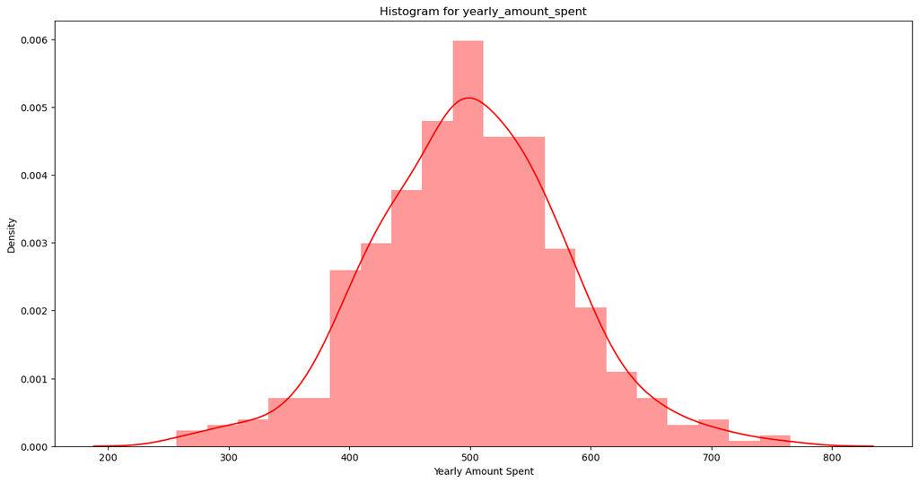

```python
# Setting plot area
f, ax = plt.subplots(figsize=(16, 8))

# plotting the distribution plot
sns.distplot(df['Yearly Amount Spent'], color="r", axlabel='Yearly Amount Spent')
ax.set(title="Histogram for yearly_amount_spent")
plt.show()
```

# Data Visualisation

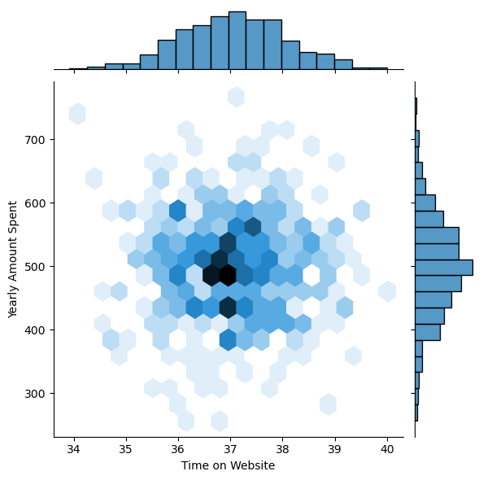

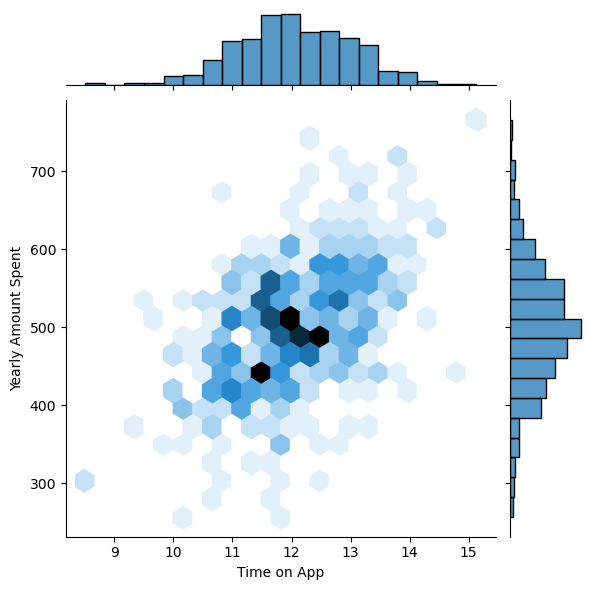

```python
sns.jointplot(data=df, x="Time on Website", y="Yearly Amount Spent", kind="hex")
sns.jointplot(data=df, x="Time on App", y="Yearly Amount Spent", kind="hex")
```

The amount of time spent on the app correlates more to yearly revenues than the amount of time spent on the website

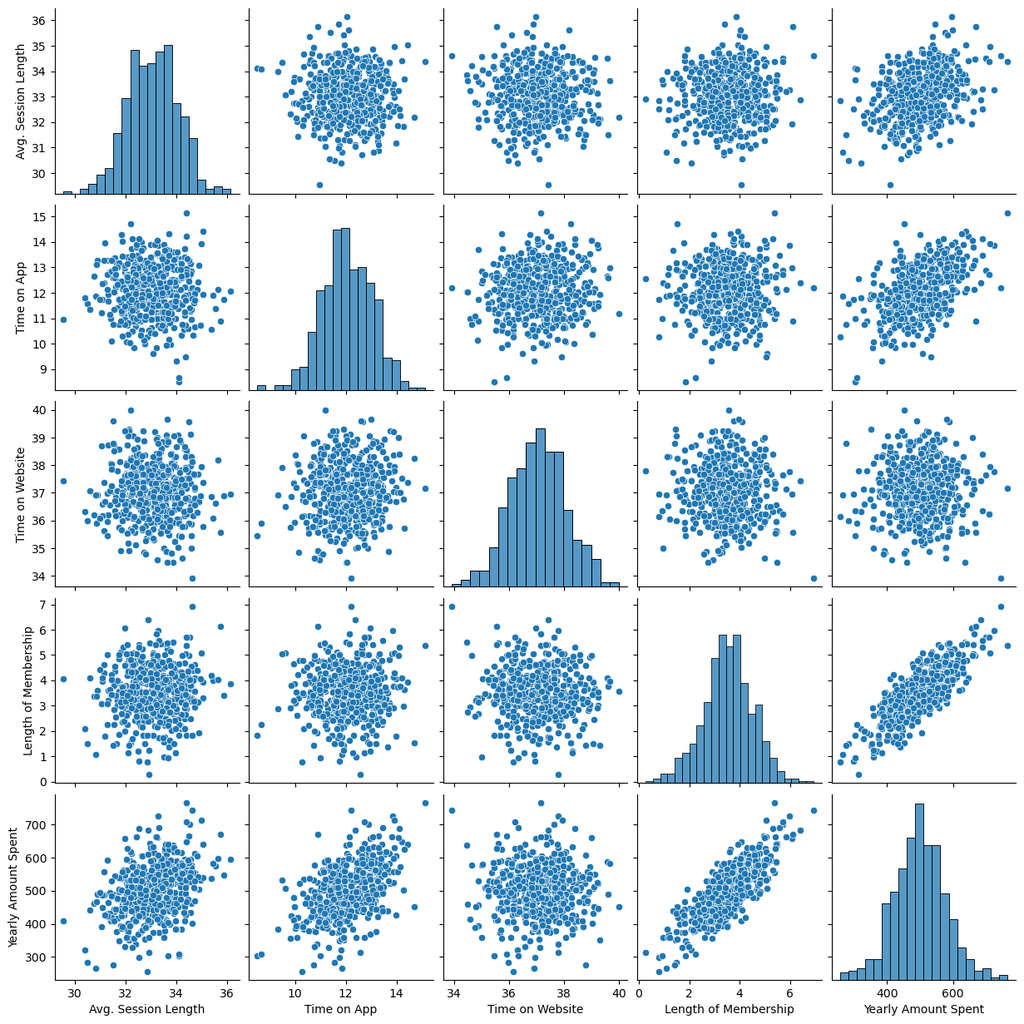

```python
sns.pairplot(df)
```

Based on this plot it seems that the length of membership feature is strongly correlated to the amount that is spent yearly.

# Regression Model

Splitting dataset into training data and testing data

Let's go ahead and split the dataset into training and testing sets. We will use the training set to train our model and use testing set to test our model.

We will set the variable 'x' equal to the numerical features of the customers. These are the features we will use to see how they increase the value of Yearly Amount Spent(i.e the 'y' variable or the sales of the company)

The variable 'y' is the "Yearly Amount Spent" column. We are trying to find out how the other features contribute in increasing the yearly Amount Spent by the customers(i.e the Sales of the company)

```python
X = df[['Avg. Session Length', 'Time on App','Time on Website', 'Length of Membership']]
y = df['Yearly Amount Spent']
```

```python
X_train, X_test, y_train, y_test = train_test_split(X, y, test_size=0.3, random_state=100)
```

# Baseline Model

- Ridge regression is a penalized linear regression model for predicting a numerical value.
- KNeighborsRegressor is a regression based on k-nearest neighbors.
- SVR is Epsilon-Support Vector Regression.
- RandomForestRegressor is a random forest.
- GradientBoostingRegressor is Gradient Boosting for regression.
- DecisionTreeRegressor is a decision tree regressor.
- AdaBoostRegressor is an AdaBoost regressor.
- ExtraTreesRegressor is an extra-trees regressor.
- XGBRegressor is an Extreme Gradient Boosting regressor.

```python
random_state=2

# Baseline cross validation
models = [
    XGBRegressor(random_state=random_state),
    SVR(),
    DecisionTreeRegressor(random_state=random_state),
    AdaBoostRegressor(DecisionTreeRegressor(random_state=random_state)),
    RandomForestRegressor(random_state=random_state),
    ExtraTreesRegressor(random_state=random_state),
    GradientBoostingRegressor(random_state=random_state),
    KNeighborsRegressor(),
    Ridge(random_state=random_state),
]

def evaluate_model(X, y, models,Kfold=5):
    performance = {}
    for model in models:
        score = cross_val_score(model, X, y, cv=Kfold).mean().round(4)*100.0
        print("Model: {}, mean cross validated score: {}%".format(type(model).__name__, score))
        performance[type(model).__name__] = score
    return performance

model_scores = evaluate_model(X_train, y_train, models)
top_models = sorted(model_scores, key=model_scores.get, reverse=True)[:5]

print("The best models are: {}".format(top_models))
```

```
Model: XGBRegressor, mean cross validated score: 94.21000000000001%
Model: SVR, mean cross validated score: -0.15%
Model: DecisionTreeRegressor, mean cross validated score: 83.69%
Model: AdaBoostRegressor, mean cross validated score: 91.5%
Model: RandomForestRegressor, mean cross validated score: 92.5%
Model: ExtraTreesRegressor, mean cross validated score: 95.54%
Model: GradientBoostingRegressor, mean cross validated score: 94.55%
Model: KNeighborsRegressor, mean cross validated score: 88.2%
Model: Ridge, mean cross validated score: 98.33%
The best models are: ['Ridge', 'ExtraTreesRegressor', 'GradientBoostingRegressor', 'XGBRegressor', 'RandomForestRegressor']
```

```python
print(GradientBoostingRegressor().get_params())
```

[output not shown]

```python
# Hyperparameter Tuning for the top models

GBR_params = {'n_estimators' : np.arange(100, 500, 50), # Number of boosting stages to perform
              'learning_rate': np.arange(0.01, 0.1, 0.01),
              'max_depth': np.arange(2, 10, 1), # Maximum depth of the individual regression estimators
              'min_samples_leaf': np.arange(100, 200, 10), # Minimum number of samples required to be at a leaf node
              'alpha': np.arange(0.7, 0.9, 0.05)
             }

Ridge_params = {'alpha': np.arange(0.1, 1.5, 0.1) # Regularization strength
               }

ExtraT_params = {'n_estimators' : np.arange(50,1000,50) # Number of trees in the forest
                }

Ada_params = {'n_estimators' : np.arange(50,1000,50),
              'learning_rate': np.arange(0.01, 0.1, 0.01)}

XGB_params = {'n_estimators' : np.arange(100, 2000, 100),
              'learning_rate': np.arange(0.01, 0.1, 0.01),
              'max_depth': np.arange(1, 10, 1) # Maximum depth of a tree
             }

RFR_parms = {'n_estimators' : np.arange(10, 1000, 250), # Number of trees in random forest
              'max_features': ['sqrt', 'log2'], # Number of features to consider at every split
              'max_depth': np.append(np.arange(10, 50, 10) ,None), # Maximum number of levels in tree
              'min_samples_leaf': np.arange(1, 15, 5), # Minimum number of samples required at each leaf node
              'min_samples_split': np.arange(2, 20, 5), # Minimum number of samples required to split a node
              'bootstrap' : [True, False] # Method of selecting samples for training each tree
            }

SVR_params = { 'kernel' : ['linear', 'poly', 'rbf', 'sigmoid'], # Kernel type to be used in the algorithm
              'epsilon': np.arange(0.1, 0.5, 0.1),
              'C': np.arange(1, 20, 1) #  Regularization parameter (a penality)
             }

KNR_params = {'leaf_size': np.arange(5, 50, 5),
              'n_neighbors': np.arange(1, 10, 3), # Number of neighbors
              'p': np.arange(1, 4, 1), # Power parameter for the Minkowski metric
             'metric' : ['euclidean', 'manhattan', 'minkowski'], # Distance metrics for choosing the composition of the neighborhood
             'weights' : ['uniform', 'distance'] # Weight function used in prediction
             }

model_list = [Ridge(), ExtraTreesRegressor(), GradientBoostingRegressor(), XGBRegressor(), RandomForestRegressor()]
param_list = [Ridge_params, ExtraT_params, GBR_params, XGB_params, RFR_parms ]

iterations = 20
best_estimators = {}

for i in range(len(model_list)):
    model_name = type(model_list[i]).__name__

#     Randomized search on hyper parameters.
# define search
    fitted_model = RandomizedSearchCV(model_list[i],
                                      param_distributions = param_list[i],
                                      n_iter=iterations,
                                      cv=5,
                                      scoring="neg_mean_squared_error", #neg_mean_absolute_error
                                      verbose=0,
                                     return_train_score = True)
# execute search to get estimators
    fitted_model.fit(X_train, y_train)
# summarize result
    print("Model: {}, best cross validated score: {}".format(model_name, -1*fitted_model.best_score_))
    print('Model: {}, best Hyperparameters: {}'.format(model_name, fitted_model.best_params_))
    #     save the best model
    best_estimators[model_name] = fitted_model.best_estimator_
```

```
Model: Ridge, best cross validated score: 98.4955447455923
Model: Ridge, best Hyperparameters: {'alpha': 0.4}
Model: ExtraTreesRegressor, best cross validated score: 264.84044216060204
Model: ExtraTreesRegressor, best Hyperparameters: {'n_estimators': 350}
Model: GradientBoostingRegressor, best cross validated score: 1874.4779718180428
Model: GradientBoostingRegressor, best Hyperparameters: {'n_estimators': 300, 'min_samples_leaf': 110, 'max_depth': 8, 'learning_rate': 0.06999999999999999, 'alpha': 0.7}
Model: XGBRegressor, best cross validated score: 191.22948238600605
Model: XGBRegressor, best Hyperparameters: {'n_estimators': 1400, 'max_depth': 1, 'learning_rate': 0.05}
Model: RandomForestRegressor, best cross validated score: 469.87977471805004
Model: RandomForestRegressor, best Hyperparameters: {'n_estimators': 760, 'min_samples_split': 2, 'min_samples_leaf': 1, 'max_features': 'sqrt', 'max_depth': 40, 'bootstrap': False}
```

```python
# A voting regressor is an ensemble meta-estimator that fits several base
# regressors, each on the whole dataset. Then it averages the individual
# predictions to form a final prediction.
voting = VotingRegressor([
    ('GradientBoostingRegressor', best_estimators['GradientBoostingRegressor']),
    ('Ridge', best_estimators['Ridge']),
    ('ExtraTreesRegressor',best_estimators['ExtraTreesRegressor']),
    ('RandomForestRegressor', best_estimators['RandomForestRegressor']),
    ('XGBRegressor', best_estimators['XGBRegressor'])
])

voting = voting.fit(X_train, y_train)
preds = voting.predict(X_test)
```

```python
best_estimators['Ridge'].coef_
```

```
array([26.12748385, 38.58008034,  0.31908648, 61.75443778])
```

```python
prediction = best_estimators['Ridge'].predict(X_test)
```

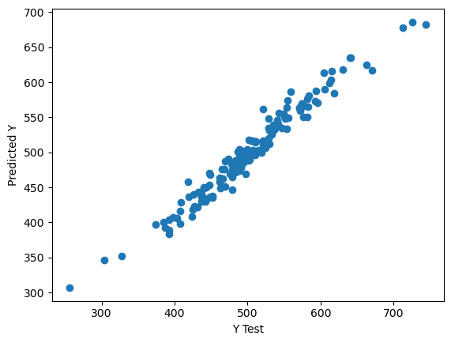

```python
plt.scatter(y_test,preds)
plt.xlabel('Y Test')
plt.ylabel('Predicted Y')
```

Well the the data points are scatttered in a line which tells us how well our predictions are correlated to the test data points

We will calculate the Mean Absolute Error (MAE), Mean Squared Error (MSE), and the Root Mean Squared Error (RMSE)

```python
from math import sqrt
print("MAE:", metrics.mean_absolute_error(y_test, preds))
print("MSE:", metrics.mean_squared_error(y_test, preds))
print("RMSE:", sqrt(metrics.mean_squared_error(y_test, preds)))
```

```
MAE: 12.240192301958222
MSE: 267.74369963555597
RMSE: 16.362875653000483
```

# Conclusion

Okay so looks like our model is ready. Time to study the features and see how they affect the yearly amount spent by the customers

```python
coeffecients = pd.DataFrame(best_estimators['Ridge'].coef_,X.columns)
coeffecients.columns = ['Coeffecient']
coeffecients
```

|  | Coeffecient |
| --- | --- |
| Avg. Session Length | 26.127484 |
| Time on App | 38.580080 |
| Time on Website | 0.319086 |
| Length of Membership | 61.754438 |

Below is what we can interpret from the coefficient of our model. Holding all the other variables fixed:

1. Avg. Session Length increases the Yearly Amount Spent by almost 26. units
2. Time on App increases the Yearly Amount Spent by 38.5 units
3. Time on Website increases the Yearly Amount Spent by 0.3 units
4. Length of Membership increases the Yearly Amount Spent by 62 units

We can conclude that the time spent on the App is more correlated to the customer's yearly expenditure and it is evident that we should focus more on building the app to draw more business from the customers.

We also noticed that the Lenght of the Membership correlates to yearly amount spend even more! Well it would be a good idea if in future we explore on how we can work on increasing the length of membership to increase customer's yearly spent amount.

Conclusion: Mobile App it is!